# Data Analysis Using Statistical Packages: Basics of Inferential Statistics

Sho Kuroda / 黒田翔

最終更新：2026年5月

このページに対応するRmdファイル：[GitHub](https://github.com/kurodaecon/dasp/blob/main/rmd/inferential_stat.Rmd)

# 1 Generating random numbers / 乱数の生成

確率分布 $F$ に従う確率変数 $X$ があったとき，この確率変数の実現値を疑似的に作り出す手続きを乱数の生成と呼ぶ．

$$X_1, \ldots, X_n \sim F$$

疑似乱数は `rxxx` 関数で生成することができる．

- `xxx` は確率分布の略称（一様分布 unif, 正規分布 norm, 二項分布 binom）

たとえば，一様分布から乱数をドローするには，`runif`関数を使う．この関数名は r (random number generation/generator) + unif (uniform distribution) から来ている．

`runif(n = サンプルサイズ, min = 下限, max = 上限)` で乱数を生成．

```r
runif(n = 5, min = 0, max = 1)
```

```
## [1] 0.39931040 0.08449545 0.28970107 0.13294273 0.89364110
```

```r
runif(5, 0, 1)  # 引数の順番を守れば「n=」などを省略可
```

```
## [1] 0.6374001 0.9334026 0.9999210 0.4302742 0.1541062
```

```r
runif(5)  # min = 0 かつ max = 1 の場合は省略可（デフォルトの設定）
```

```
## [1] 0.2985820 0.5381468 0.6767923 0.3518814 0.1843144
```

乱数をドローするたびに異なる値が出力される．

## 1.1 Set a seed

再現性のために乱数のシードを指定することができる．

```r
set.seed(0)
runif(5)
```

```
## [1] 0.8966972 0.2655087 0.3721239 0.5728534 0.9082078
```

```r
set.seed(0)
runif(5)
```

```
## [1] 0.8966972 0.2655087 0.3721239 0.5728534 0.9082078
```

# 2 Probability and Probability distribution / 確率と確率分布

## 2.1 Bernoulli distribution / ベルヌーイ分布

$$\Pr(X = 1) = p, \quad \Pr(X = 0) = 1-p$$

例：60%の確率で表が出るコインをトスし，表が出れば1，裏が出れば0とする．

```r
rbinom(n = 1, size = 1, prob = 0.6)
```

```
## [1] 1
```

```r
table(rbinom(n = 10000, size = 1, prob = 0.6))
```

```
##
##    0    1
## 3969 6031
```

確率分布（確率変数が取りうる値とその確率を対応させたもの）は次の通り．

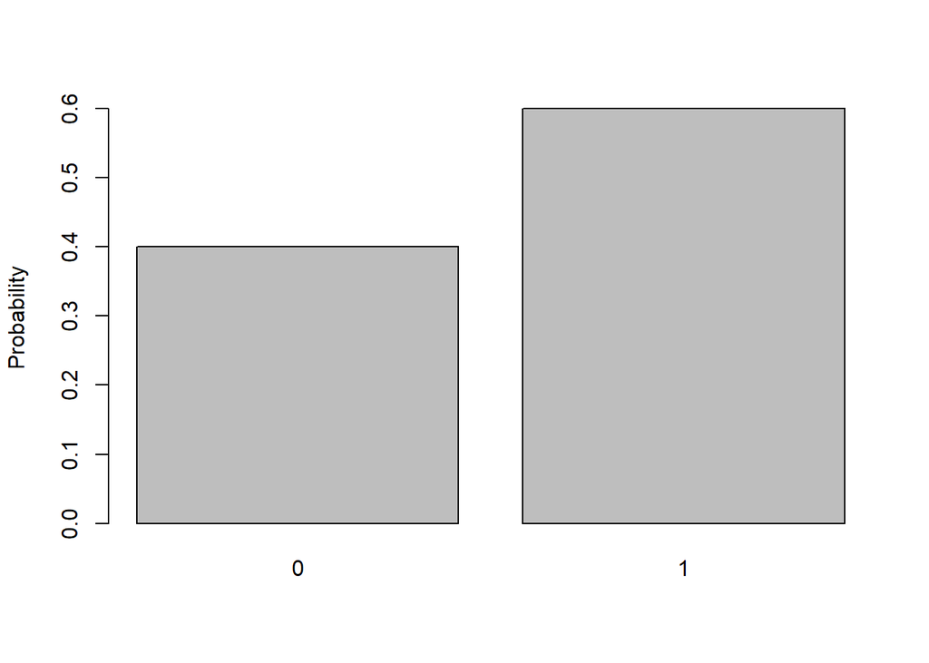

```r
barplot(c(0.4, 0.6), names.arg = 0:1, ylab = "Probability")
```

## 2.2 Binomial distribution / 二項分布

$$\Pr(X = k) = \binom{n}{k} p^k
(1-p)^{n-k}$$

例：60%の確率で表が出るコインを5回トスしたときに表が出る回数．

```r
rbinom(n = 1, size = 5, prob = 0.6)
```

```
## [1] 4
```

```r
table(rbinom(n = 10000, size = 5, prob = 0.6))
```

```
##
##    0    1    2    3    4    5
##   90  790 2299 3468 2578  775
```

上の式より，表が 0, 1, 2, 3, 4, 5 回出る理論上の確率は次のように計算される．

```r
binom_prob <- c(
  choose(5, 0) * 0.6^0 * (1 - 0.6)^(5 - 0),  # choose(n, k) = nCk
  choose(5, 1) * 0.6^1 * (1 - 0.6)^(5 - 1),
  choose(5, 2) * 0.6^2 * (1 - 0.6)^(5 - 2),
  choose(5, 3) * 0.6^3 * (1 - 0.6)^(5 - 3),
  choose(5, 4) * 0.6^4 * (1 - 0.6)^(5 - 4),
  choose(5, 5) * 0.6^5 * (1 - 0.6)^(5 - 5))
binom_prob
```

```
## [1] 0.01024 0.07680 0.23040 0.34560 0.25920 0.07776
```

よって，確率分布は次の通り．

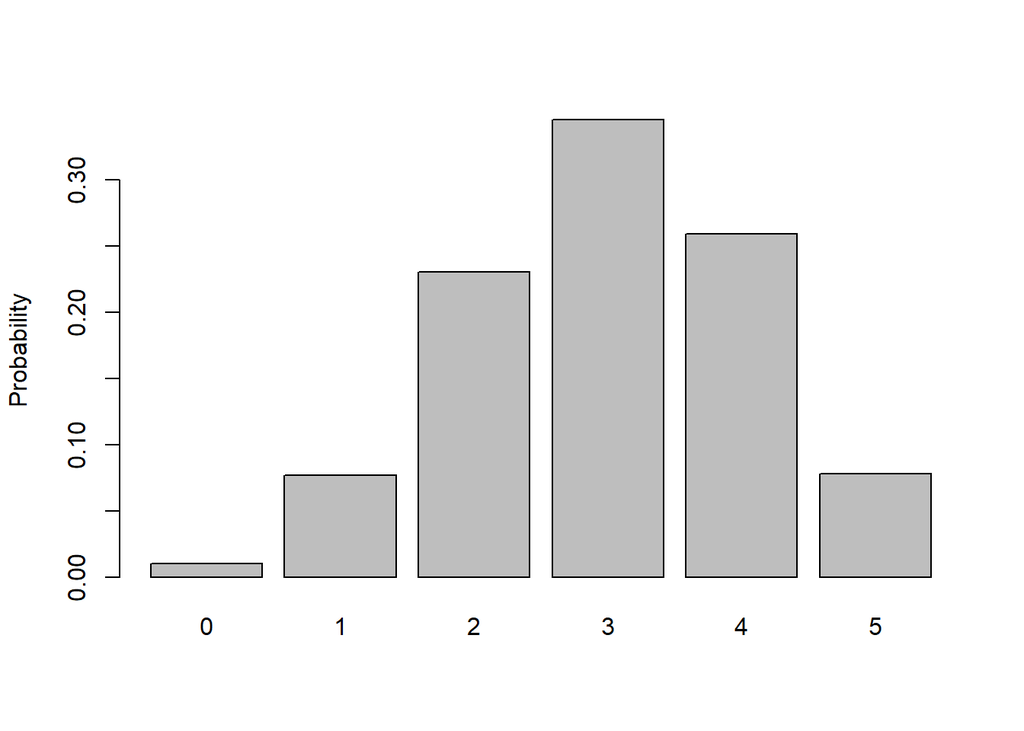

```r
barplot(binom_prob, names.arg = 0:5, ylab = "Probability")
```

## 2.3 Uniform distribution / 一様分布

$$X \sim U(\mbox{min}, \mbox{max})$$

```r
runif(n = 1, min = 0, max = 1)
```

```
## [1] 0.117898
```

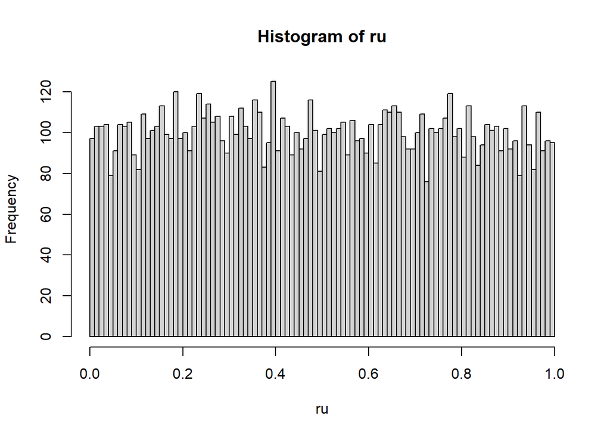

```r
ru <- runif(n = 10000, min = 0, max = 1)
hist(ru, breaks = 100)
```

### 2.3.1 Probability

連続確率変数について所与の区間の値を取る確率は密度関数 $f$ を用いて次で与えられる（ただし $\mbox{min} \le a \le b \le \mbox{max}$）．

$$\Pr(a \le X \le b) = \int_a^b f(x) dx =
\int_a^b \frac{1}{\mbox{max} - \mbox{min}} dx$$

最小値0，最大値1の一様分布の場合は次のとおり（ただし $0 \le a \le b \le 1$）．

$$\Pr(a \le X \le b) = \int_a^b
\frac{1}{1-0} dx = b-a$$

たとえば $\Pr(0.2 \le X \le 0.9) = 0.7$ である．

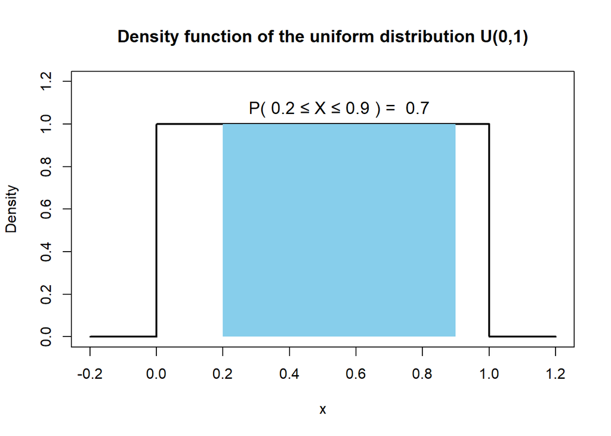

```r
head(data.frame(random_num = ru, is_in_range = ru >= 0.2 & ru <= 0.9))
```

```
##   random_num is_in_range
## 1  0.4772929        TRUE
## 2  0.7689994        TRUE
## 3  0.6008625        TRUE
## 4  0.2997955        TRUE
## 5  0.6545341        TRUE
## 6  0.3811610        TRUE
```

```r
table(ru >= 0.2 & ru <= 0.9)
```

```
##
## FALSE  TRUE
##  2944  7056
```

分布関数 $F$ に基づいて下図のように考えてもよい．

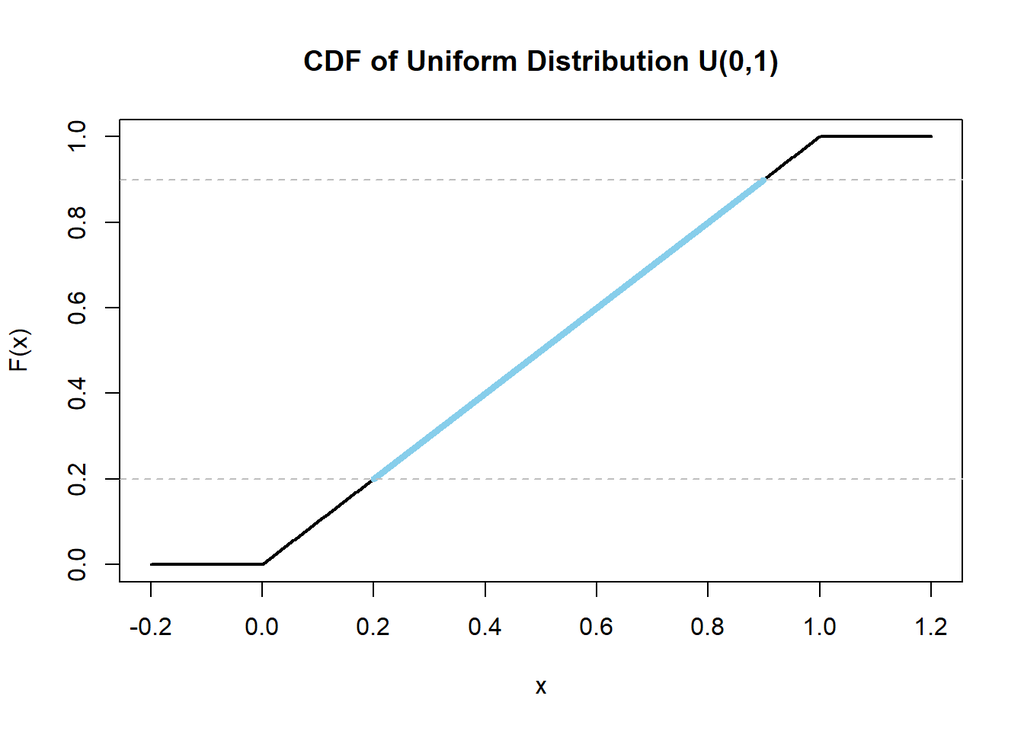

この場合，所与の $x$ の値に対応する累積確率を返す関数 `punif` を用いて次のように計算することもできる． 関数名は p (probability) + unif より．

```r
punif(0.9) - punif(0.2)
```

```
## [1] 0.7
```

つまり，`punif` 関数と密度関数 $f$ および分布関数 $F$ は次のような関係にある．

$$\texttt{punif}(x, \text{min},
\text{max}) = \int_{\text{min}}^{x} f(u) du = F(x) = \Pr(X \le x)$$
$$\text{where} \quad f(u) =
\frac{1}{\text{max} - \text{min}}$$

## 2.4 Normal distribution / 正規分布

$$X \sim N(\mu, \sigma^2)$$

```r
rnorm(n = 1, mean = 0, sd = 1)
```

```
## [1] 0.9210962
```

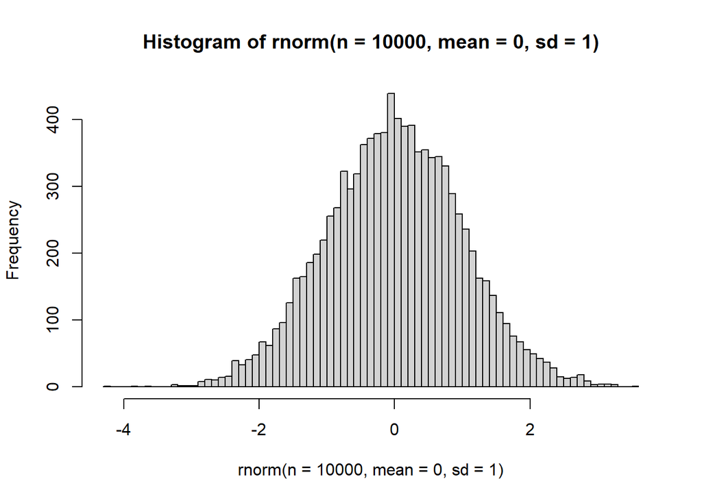

```r
hist(rnorm(n = 10000, mean = 0, sd = 1), breaks = 100)
```

### 2.4.1 Probability

平均 0 分散 1 の正規分布を標準正規分布と呼ぶ．

$$Z \sim N(0, 1)$$

標準正規分布の密度関数 $\phi$ について $z = 1.96$ より左側の面積は確率 $\Pr(Z \le 1.96)$ である．

$$\Pr(Z \le 1.96) = \int_{-\infty}^{1.96}
\phi (x) dx$$

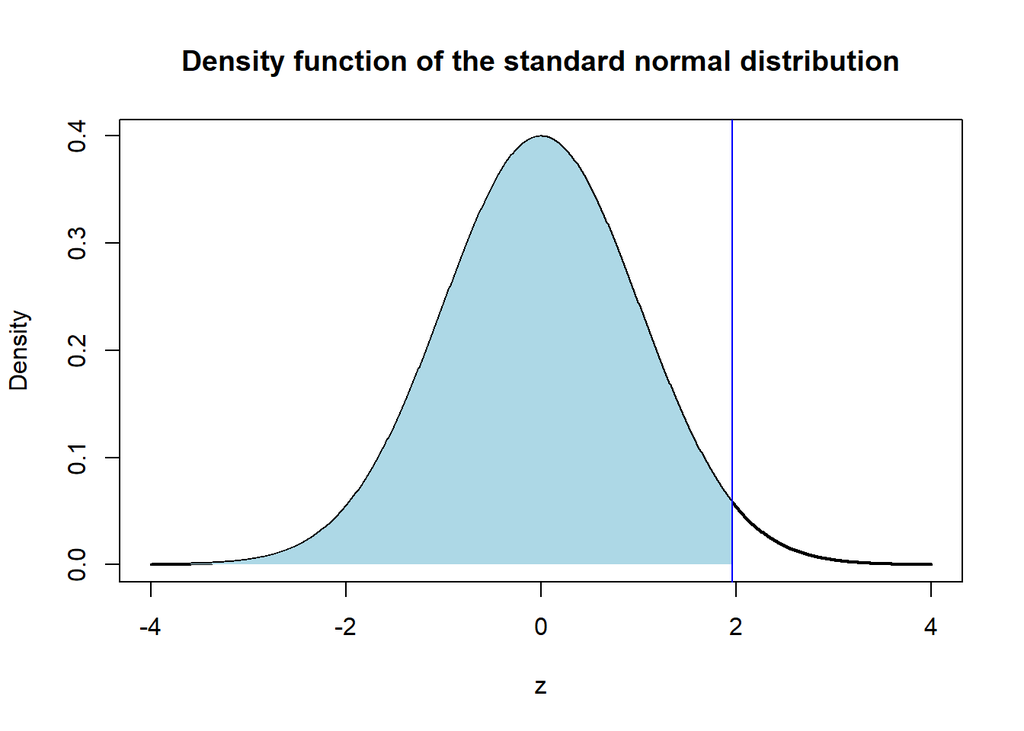

一様分布のときと同様に，累積分布関数に基づいて次のように計算できる．

`pnorm` は与えられた $z$ スコアに対応する累積確率を返す関数． 関数名は p (probability) + norm (normal distribution) から来ている．

```r
pnorm(q = 1.96, mean = 0, sd = 1)
```

```
## [1] 0.9750021
```

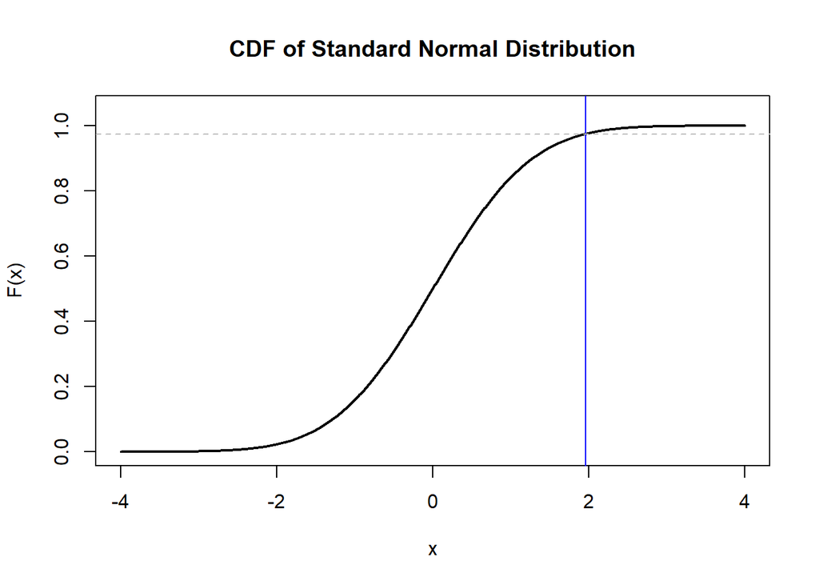

次のように正規乱数を用いて確認することもできる．

```r
rn <- rnorm(n = 10000, mean = 0, sd = 1)
head(data.frame(random_num = rn, is_in_range = rn <= 1.96))
```

```
##   random_num is_in_range
## 1  0.9134180        TRUE
## 2 -2.8988797        TRUE
## 3 -0.0213748        TRUE
## 4 -0.9831606        TRUE
## 5  0.1166303        TRUE
## 6 -0.1551706        TRUE
```

```r
table(rn <= 1.96)
```

```
##
## FALSE  TRUE
##   265  9735
```

### 2.4.2 `qnorm`

`pnorm` とは逆に，`qnorm` は与えられた確率に対応する $z$ スコアを返す関数．

```r
qnorm(p = 0.975, mean = 0, sd = 1)
```

```
## [1] 1.959964
```

```r
qnorm(p = 0.975)  # for N(0,1), the mean and sd arguments may be omitted
```

```
## [1] 1.959964
```

### 2.4.3 `dnorm`

確率密度． `dnorm` = d (density) + norm (normal distribution).

```r
dnorm(x = 1.96, mean = 0, sd = 1)
```

```
## [1] 0.05844094
```

標準正規分布の確率密度 $\phi$ を積分する（確率密度関数とX軸の間の面積を計算する）と，積分区間の間の値を取る確率が得られる．

$$\Pr(-1.96 \le Z \le 1.96) =
\int_{-1.96}^{1.96} \phi(z) dz \approx 0.95$$

```r
integrate(dnorm, -1.96, 1.96)  # 積分: 約 95%
```

```
## 0.9500042 with absolute error < 1e-11
```

# 3 Expectation and Variance of a random variable

離散確率変数 $X$ の期待値と分散は確率関数 $f$ を用いて以下のように定義される．

$$\mu = E(X) = \sum_j x_j f(x_j)$$

$$\sigma^2 = V(X) = E[(X-E(X))^2] =
\sum_j (x_j - E(X))^2 f(x_j) = E(X^2) - (E(X))^2$$

連続確率変数の場合（ここでは $f$ は確率密度関数）

$$\mu = E(X) = \int_{-\infty}^{\infty} x
f(x) dx$$

$$\sigma^2 = V(X) =
\int_{-\infty}^{\infty} (x - \mu)^2 f(x) dx$$

## 3.1 Dice roll

例：サイコロの出目 $X$ の期待値と分散 / Example of dice roll

$$E(X) = \sum_{j=1}^6 x_j \frac{1}{6} = 1
\times \frac{1}{6} + 2 \times \frac{1}{6} + 3 \times \frac{1}{6} + 4
\times \frac{1}{6} + 5 \times \frac{1}{6} + 6 \times \frac{1}{6} =
\frac{7}{2}$$

```r
dice <- 1:6  # c(1, 2, 3, 4, 5, 6) と同じ
sum(dice * (1/6))  # definition of expectation
```

```
## [1] 3.5
```

```r
mean(dice)  # mean
```

```
## [1] 3.5
```

$$V(X) = \sum_{j=1}^6 (x_j - E(X))^2
\frac{1}{6} = \left( 1-\frac{7}{2} \right) ^2 \frac{1}{6} + \left(
2-\frac{7}{2} \right) ^2 \frac{1}{6} + \cdots + \left( 6-\frac{7}{2}
\right) ^2 \frac{1}{6} \approx 2.917$$

```r
sum((dice - mean(dice))^2 * (1/6))  # variance: sum[(x-E(X))^2 * f(x)]
```

```
## [1] 2.916667
```

なお，`var(dice)` は 3.5 となり，上記と一致しないが，これは `var` 関数が標本を引数として標本分散（不偏分散）を計算するためである． `dice` は母集団から抽出された標本ではないため，標本分散として確率変数の分散を求めることはできない．

$V(X) = E(X^2) - (E(X))^2$ でもある．

```r
sum(dice^2 * (1/6)) - sum(dice * (1/6))^2  # variance: E(X^2)-E(X)^2
```

```
## [1] 2.916667
```

## 3.2 Uniformly distributed random variable

一様分布 $U(a, b)$ から乱数を生成して標本平均と標本分散を計算し，それが理論値と一致するかを確認する．

$$E(X) = \int_a^b x \frac{1}{b-a} dx =
\frac{1}{b-a} \left[ \frac{x^2}{2} \right]_a^b = \frac{1}{b-a} \times
\frac{b^2 - a^2}{2} = \frac{a+b}{2}$$

$$V(X) = \int_a^b (x - \mu)^2
\frac{1}{b-a} dx = \frac{1}{b-a} \left[ \frac{ \left( x - \frac{a+b}{2}
\right)^3}{3} \right]_a^b = \frac{(b - a)^2}{12}$$

$X \sim U(-1, 1)$ とすると，期待値と分散は次の値となる．

$$E(X) = \frac{a+b}{2} = \frac{-1+1}{2} =
0$$

$$V(X) = \frac{(b - a)^2}{12} = \frac{(1
- (-1))^2}{12} = \frac{1}{3}$$

「サンプルサイズ 100 で一様乱数を生成して平均と分散を計算する」を 1,000 回繰り返し，1,000個の平均と分散の分布を観察する． このようなシミュレーションを「モンテカルロ・シミュレーション」と呼ぶ．

- `for` 文を使って，乱数生成，平均と分散の計算，記録を行う
  - 計算結果を格納するオブジェクトを `runif_mean` と `runif_var` という名前で作成．`NULL` を代入して空のオブジェクトを作成
  - `c(直前までの計算結果のベクトル, 今回の計算結果)` で append （値を末尾に追加）

```r
runif_mean <- NULL  # 標本平均を格納しておくオブジェクト
runif_var <- NULL  # 標本分散を 〃
for (i in 1:1000) {
  set.seed(i)  # 再現性のため
  # 乱数を生成
  runif_i <- runif(n = 100, min = -1, max = 1)
  # 平均・分散を計算して上で作成したオブジェクトに格納 (append)
  runif_mean <- c(runif_mean, mean(runif_i))
  runif_var <- c(runif_var, var(runif_i))
}
summary(runif_mean)
```

```
##       Min.    1st Qu.     Median       Mean    3rd Qu.       Max.
## -1.842e-01 -4.050e-02 -4.024e-05 -1.030e-03  3.643e-02  2.225e-01
```

```r
summary(runif_var)
```

```
##    Min. 1st Qu.  Median    Mean 3rd Qu.    Max.
##  0.2413  0.3127  0.3327  0.3333  0.3545  0.4225
```

# 4 Law of large numbers / 大数の法則

ラフに言えば，サンプルサイズが大きくなれば標本平均が母平均に収束するという法則．

確率変数 $X_1, \ldots, X_n$ が互いに独立に同一の分布に従い $E(X_i) = \mu < \infty$ のとき，任意の $\epsilon > 0$ に対して次が成立（証明はチェビシェフの不等式によるものが有名）．

$$\Pr ( |\bar{X} - \mu| \le \epsilon )
\to 1 \quad (\mbox{as } n \to \infty)$$

正規分布に従う確率変数 $X_i \sim N(0, 1)$ の実現値の標本平均（累積平均） $\bar{x}_n = (1/n) \sum_{i=1}^n x_i$ がサンプルサイズ $n$ とともにどのように変化するかを観察する．

```r
rn <- rn_mean <- NULL
for (i in 1:10000) {
  rn <- c(rn, rnorm(n = 1))
  rn_mean <- c(rn_mean, mean(rn))
}
head(cbind(random_num = rn, cumulative_mean = rn_mean))
```

```
##      random_num cumulative_mean
## [1,]  0.2517114      0.25171138
## [2,] -1.0946937     -0.42149116
## [3,]  0.3976428     -0.14844649
## [4,] -0.9963020     -0.36041037
## [5,]  0.1005780     -0.26821269
## [6,]  0.9536803     -0.06456386
```

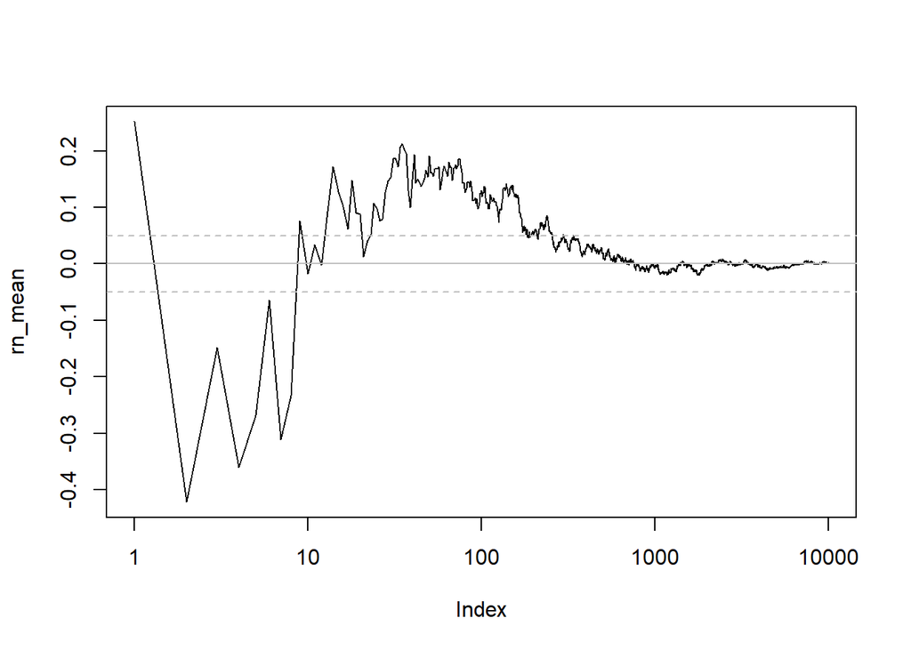

```r
plot(rn_mean, type = "l", log = "x")
abline(h = 0, col = "grey", lty = 1)  # mu = 0 (true mean)
abline(h = c(0.05, -0.05), col = "grey", lty = 2)  # epsilon = 0.05
```

余談だが，実は次のような短いコードでも同じ（出力は省略）．

```r
plot(cumsum(rnorm(n = 10000)) / 1:10000, type = "l", log = "x")
```

# 5 Central limit theorem / 中心極限定理

サンプルサイズが十分に大きいとき，平均 $\mu$ 分散 $\sigma^2$ の母集団から得られた標本の平均 $\bar{X}$ は近似的に正規分布に従う．

$$\bar{X} \sim N \left( \mu,
\frac{\sigma^2}{n} \right)$$

ポイント

- 一つの標本から計算される標本平均は特定の値 $\bar{x}$ をとるが，同じ母集団から何度もサンプリングを行いその度に繰り返し標本平均を計算すればその標本平均はばらつく．これを確率変数 $\bar{X}$ として扱う．
- サンプルサイズ $n$ が大きくなると標本平均は母平均に近い値を取り，標本平均の標本分布は正規分布に近似される（例外あり）．
- 中心極限定理は母平均の信頼区間の計算や平均値の差の検定を行う上で重要．

以下では一様確率変数の標本平均の分布を求める．標本サイズが大きくなるほど正規分布に近づき，分布の分散が小さくなることが分かる．

## 5.1 $n=1$

これは乱数そのものの分布と等しい．

$$\bar{X} = X_i, \quad X_i \sim U(0, 1)$$

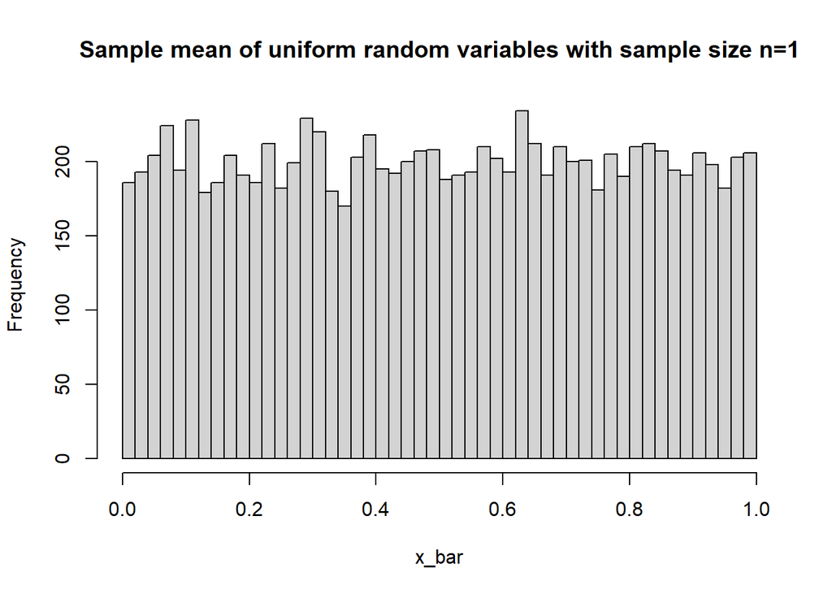

```r
x_bar <- NULL  # create empty (null) object
for (i in 1:10000) {
  x_bar_i <- mean(runif(n = 1, min = 0, max = 1))
  x_bar <- c(x_bar, x_bar_i)
}
hist(x_bar, breaks = 50, main = "Sample mean of uniform random variables with sample size n=1")
```

```r
var(x_bar)  # シミュレーションによる分散
```

```
## [1] 0.08302284
```

```r
(1/12) / 1  # 理論上の分散
```

```
## [1] 0.08333333
```

## 5.2 $n=2$

$$\bar{X} = \frac{1}{2} \sum_{i=1}^{2}
X_i, \quad X_i \sim U(0, 1)$$

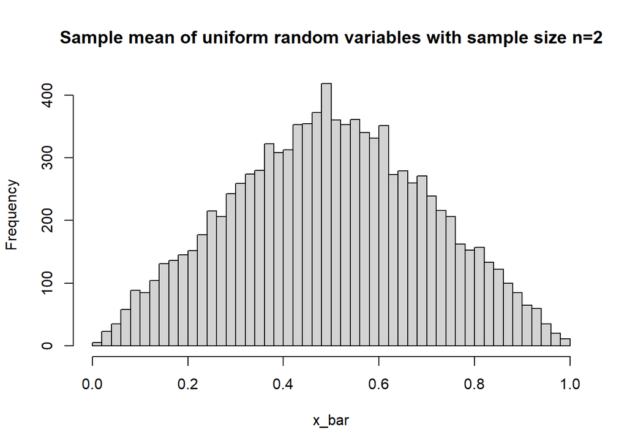

```r
x_bar <- NULL
for (i in 1:10000) {
  x_bar_i <- mean(runif(n = 2, min = 0, max = 1))
  x_bar <- c(x_bar, x_bar_i)
}
hist(x_bar, breaks = 50, main = "Sample mean of uniform random variables with sample size n=2")
```

```r
var(x_bar)  # シミュレーションによる分散
```

```
## [1] 0.04145714
```

```r
(1/12) / 2  # 理論上の分散
```

```
## [1] 0.04166667
```

## 5.3 $n=10$

$$\bar{X} = \frac{1}{10} \sum_{i=1}^{10}
X_i, \quad X_i \sim U(0, 1)$$

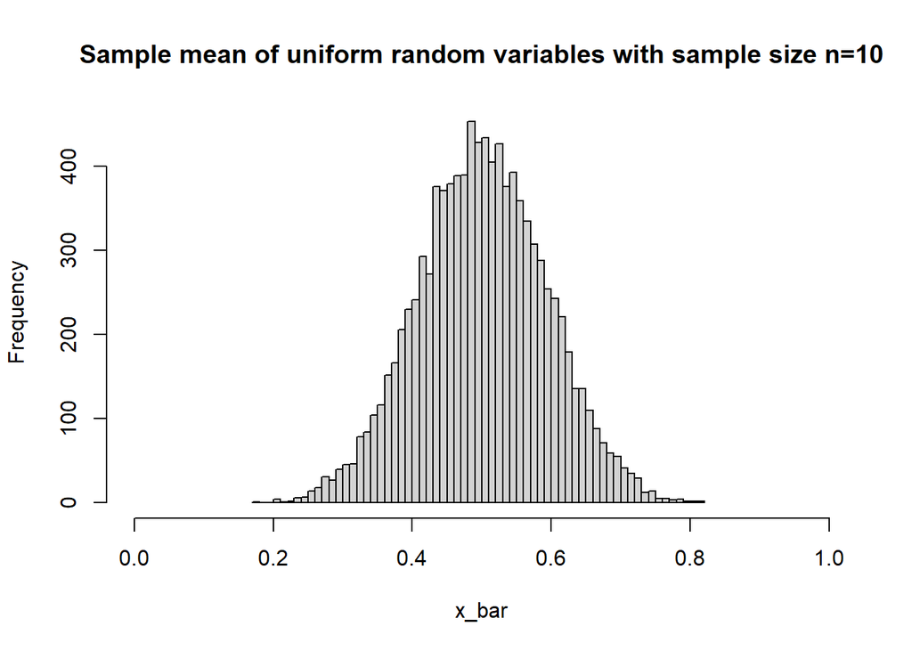

```r
x_bar <- NULL
for (i in 1:10000) {
  x_bar_i <- mean(runif(n = 10, min = 0, max = 1))
  x_bar <- c(x_bar, x_bar_i)
}
hist(x_bar, breaks = 50, main = "Sample mean of uniform random variables with sample size n=10",
     xlim = c(0, 1))
```

```r
var(x_bar)  # シミュレーションによる分散
```

```
## [1] 0.008489861
```

```r
(1/12) / 10  # 理論上の分散
```

```
## [1] 0.008333333
```

## 5.4 For advanced students / 中級者向け

`for` 文を使わずに `sapply` 関数を使って次のように書くこともできる：

```r
hist(sapply(X = 1:10000, FUN = function(x) mean(runif(10)) ), breaks = 50)
```

（出力は省略）

## 5.5 Normal distribution, $n=2$

正規母集団の場合はサンプルサイズが小さくても正規分布に従う（再生性と呼ばれる性質）．

$$\bar{X} = \frac{1}{2} \sum_{i=1}^2 X_i,
\quad X_i \sim N(0, 1)$$

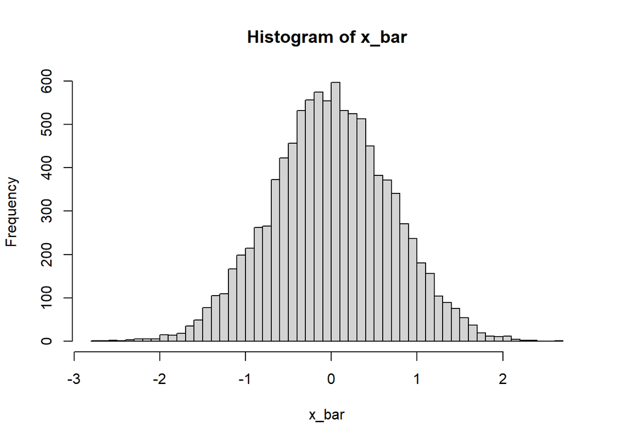

```r
x_bar <- NULL
for (i in 1:10000) {
  x_bar_i <- mean(rnorm(n = 2, mean = 0, sd = 1))
  x_bar <- c(x_bar, x_bar_i)
}
hist(x_bar, breaks = 50)
```

```r
var(x_bar)  # シミュレーションによる分散
```

```
## [1] 0.4913276
```

```r
1 / 2  # 理論上の分散
```

```
## [1] 0.5
```

この性質は，たとえばt検定による平均値の差の検定を適用してよいか判断する際の次の条件と関連する．

- 母集団が正規分布であるか分からないがサンプルサイズが大きい → 中心極限定理により $\bar{X} \sim N$
- 母集団が正規分布 → 正規分布の再生性により $\bar{X} \sim N$

## 5.6 Log-normal distribution, $n=10$

母集団分布の形状によってはサンプルサイズが小さいと正規分布で十分に近似できない． たとえば，対数正規分布のような歪んだ分布からサンプリングされた標本の場合は次のようになる．

$$\bar{X} = \frac{1}{10} \sum_{i=1}^{10}
X_i, \quad X_i \sim \ln N(0, 1)$$

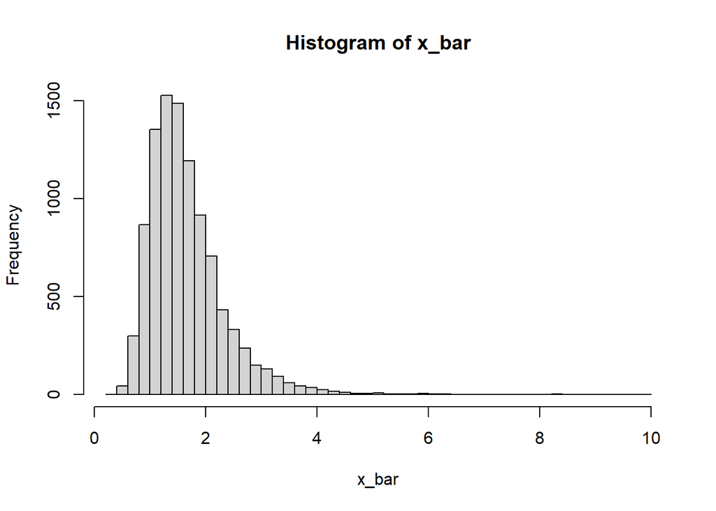

```r
x_bar <- NULL
for (i in 1:10000) {
  x_bar_i <- mean(rlnorm(n = 10, meanlog = 0, sdlog = 1))
  x_bar <- c(x_bar, x_bar_i)
}
hist(x_bar, breaks = 50)
```

```r
var(x_bar)  # シミュレーションによる分散
```

```
## [1] 0.4735483
```

```r
(exp(2) - exp(1)) / 10  # 理論上の分散
```

```
## [1] 0.4670774
```

# 6 Distribution of standardized $\bar{X}$ / 標準化した $\bar{X}$ の分布

母集団が平均 $\mu$，分散 $\sigma^2$ の正規分布であるとする．

正規分布の再生性により $\bar{X} \sim N$ である．

## 6.1 Known $\sigma$

母分散 $\sigma^2$ が既知のとき，これを用いて標準化した $\bar{X}$ は次のように分布する．

$$Z = \frac{\bar{X} - \mu}{\sigma /
\sqrt{n}} \sim N(0,1)$$

「正規分布 $N(1,2^2)$ から乱数をドローして標本平均を計算し標準化する」を繰り返し，その分布を調べる．

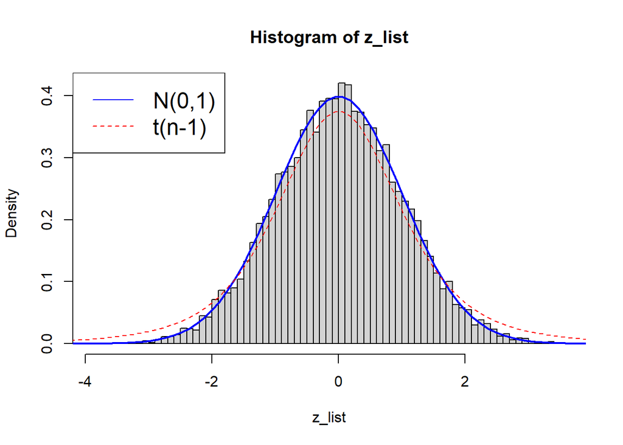

```r
z_list <- NULL
for (i in 1:10000) {
  z_i <- (mean(rnorm(n = 5, mean = 1, sd = 2)) - 1) / (2/sqrt(5))
  z_list <- c(z_list, z_i)
}
hist(z_list, probability = TRUE, breaks = 100)
z_vals <- seq(-6, 6, length.out = 100)
lines(z_vals, dnorm(z_vals), col = "blue", lwd = 2)  # N
lines(z_vals, dt(z_vals, df = 5 - 1), col = "red", lty = 2)  # t(n-1) (for reference)
legend(x = "topleft", legend = c("N(0,1)", "t(n-1)"), col = c("blue", "red"), lty = 1:2, cex = 1.5)
```

よって，標本平均の確率変数が実際に観察されたある値 $\bar{x}$ 以上の値をとる確率 $\Pr(\bar{X} \ge \bar{x})$ は次のように計算できる．

$$\Pr(\bar{X} \ge \bar{x}) = \Pr \left(
\frac{\bar{X} - \mu}{\sigma / \sqrt{n}} \ge \frac{\bar{x} - \mu}{\sigma
/ \sqrt{n}} \right) = \Pr(Z \ge z_{\bar{x}}), \quad Z \sim N(0,1)$$

## 6.2 Unknown $\sigma$

母分散 $\sigma^2$ が未知のとき，この推定値である標本分散を用いて標準化した $\bar{X}$ は次のように分布する．

$$T = \frac{\bar{X} - \mu}{s / \sqrt{n}}
\sim t(n-1) \quad \mbox{where} \quad s^2 = \frac{1}{n-1} \sum_i
(X_i-\bar{X})^2$$

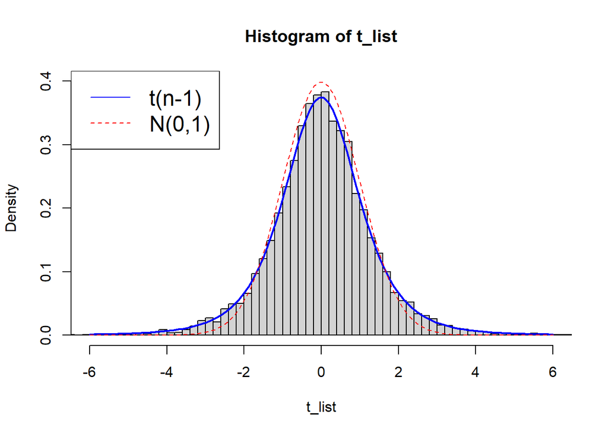

```r
t_list <- NULL
for (i in 1:10000) {
  data_i <- rnorm(n = 5, mean = 1, sd = 2)
  t_i <- (mean(data_i) - 1) / (sd(data_i)/sqrt(5))
  t_list <- c(t_list, t_i)
}
hist(t_list, probability = TRUE, breaks = 200, xlim = c(-6, 6), ylim = c(0, 0.4))
t_vals <- seq(-6, 6, length.out = 100)
lines(t_vals, dt(t_vals, df=5-1), col = "blue", lwd = 2)  # t(n-1)
lines(t_vals, dnorm(t_vals), col = "red", lty = 2)  # N(0,1) (for reference)
legend(x = "topleft", legend = c("t(n-1)", "N(0,1)"), col = c("blue", "red"), lty = 1:2, cex = 1.5)
```

よって，標本平均の確率変数が実際に観察されたある値 $\bar{x}$ 以上の値をとる確率 $\Pr(\bar{X} \ge \bar{x})$ は次のように計算できる．

$$\Pr(\bar{X} \ge \bar{x}) = \Pr \left(
\frac{\bar{X} - \mu}{s / \sqrt{n}} \ge \frac{\bar{x} - \mu}{s /
\sqrt{n}} \right) = \Pr(T_{\rm{df}=n-1} \ge t_{\bar{x}}), \quad
T_{\rm{df}=n-1} \sim t(n-1)$$

# 7 Confidence interval / 信頼区間

パラメタ $\theta$ に関する信頼水準 $(1-\alpha)$ の信頼区間 $[\hat{\theta}_\mbox{lower}, \hat{\theta}_\mbox{upper}]$ は，直感的には次のように理解できる．

$$\Pr(\hat{\theta}_\mbox{lower} \le
\theta \le \hat{\theta}_\mbox{upper}) = 1 - \alpha$$

たとえば，母平均 $\mu$ の95%信頼区間は $\sigma$ が既知の場合次のように求められる．

$$\Pr \left( -1.96 \le \frac{\bar{X} -
\mu}{\sigma/\sqrt{n}} \le 1.96 \right) = 0.95$$
$$\therefore \Pr \left( \bar{X} - 1.96 \times
\frac{\sigma}{\sqrt{n}} \le \mu \le \bar{X} + 1.96 \times
\frac{\sigma}{\sqrt{n}} \right) = 0.95$$

## 7.1 Population mean with known $\sigma$ / 母集団の標準偏差が既知の場合の母平均

標本平均が100，「母集団」の標準偏差が2，サンプルサイズが100の場合，信頼水準95%の信頼区間は次のように計算される．

$$\bar{x} \pm z \frac{\sigma}{\sqrt{n}} =
100 \pm 1.96 \frac{2}{\sqrt{100}} = 100 \pm 0.392, \quad \mbox{95% CI}:
[99.61, 100.39]$$

$z = 1.96$ は，標準正規分布に従う確率変数 $Z$ について $\Pr(Z \le z) = 0.975$ を満たす値．

```r
# qnorm(p = 0.025, mean = 0, sd = 1)  # P(Z<z) = 0.025
qnorm(p = 0.975, mean = 0, sd = 1)  # P(Z<z) = 0.975
```

```
## [1] 1.959964
```

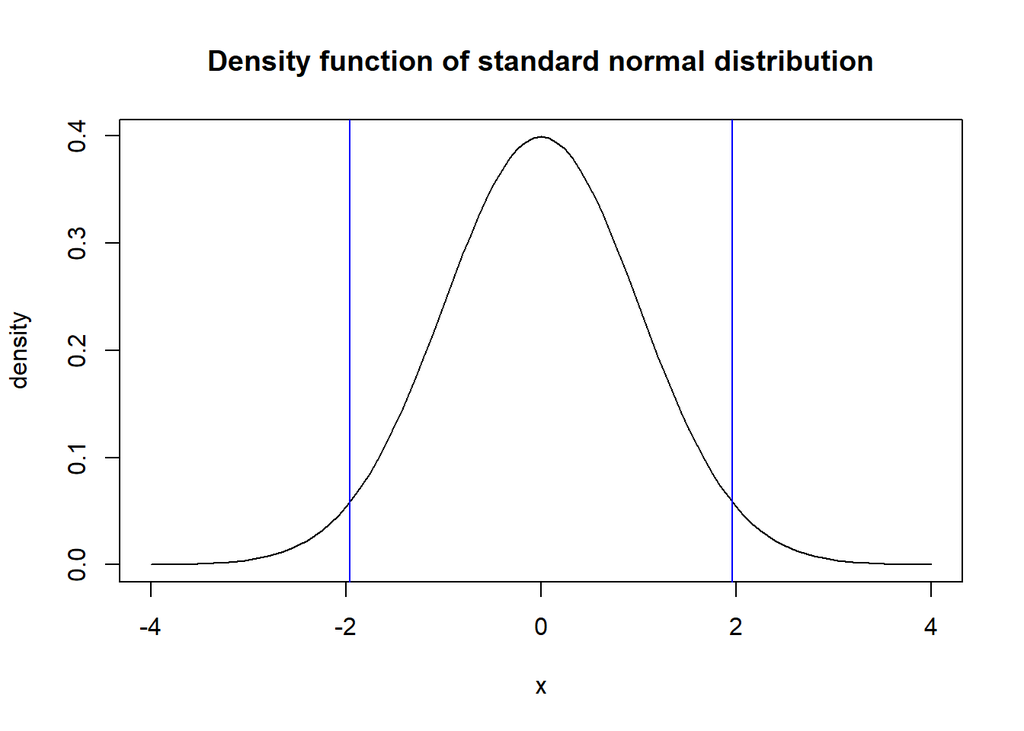

```r
100 - qnorm(p = 0.975) * 2 / sqrt(100)  # lower limit
```

```
## [1] 99.60801
```

```r
100 + qnorm(p = 0.975) * 2 / sqrt(100)  # upper limit
```

```
## [1] 100.392
```

### 7.1.1 Simulation

信頼区間とは，同じ母集団から何度も繰り返し「サンプリング → 母平均の信頼区間を計算」をしたときに，母平均が $(1-\alpha)$ の割合で含まれる区間である．

このことを，次のようなシミュレーションで確認してみよう．

- 母集団 … 母平均 $\mu = 100$, 母分散 $\sigma^2 = 2^2=4$ の正規分布
- 標本と信頼水準 … サンプルサイズ $n = 100$, $\alpha = 0.05$

```r
ci_list <- NULL
for (i in 1:1000) {
  sample_i <- rnorm(n = 100, mean = 100, sd = 2)
  ci_i_lower <- mean(sample_i) - (1.96 * 2 / sqrt(100))
  ci_i_upper <- mean(sample_i) + (1.96 * 2 / sqrt(100))
  ci_list <- rbind(ci_list, c(lower = ci_i_lower, upper = ci_i_upper))
}
ci_list <- data.frame(ci_list, is_incl_mu = ci_list[,1] <= 100 & ci_list[,2] >= 100)
head(ci_list)
```

```
##      lower    upper is_incl_mu
## 1 99.78622 100.5702       TRUE
## 2 99.31936 100.1034       TRUE
## 3 99.82596 100.6100       TRUE
## 4 99.61354 100.3975       TRUE
## 5 99.66353 100.4475       TRUE
## 6 99.63038 100.4144       TRUE
```

```r
table(ci_list$is_incl_mu)
```

```
##
## FALSE  TRUE
##    54   946
```

## 7.2 Population mean with unknown $\sigma$ / 母集団の標準偏差が未知の場合の母平均

標本平均が100，「標本」標準偏差が2，サンプルサイズが100の場合，信頼水準95%の信頼区間は次のようになる．

$$\bar{x} \pm t \frac{s}{\sqrt{n}} = 100
\pm 1.98 \frac{2}{\sqrt{100}} = 100 \pm 0.396, \quad \mbox{95% CI}:
[99.60, 100.40]$$

```r
qt(p = 0.975, df = 100-1)  # P(T<t) = 0.975
```

```
## [1] 1.984217
```

```r
100 - qt(p = 0.975, df = 100-1) * 2 / sqrt(100)  # lower limit
```

```
## [1] 99.60316
```

```r
100 + qt(p = 0.975, df = 100-1) * 2 / sqrt(100)  # upper limit
```

```
## [1] 100.3968
```

### 7.2.1 Using `t.test` function

$t$-検定を行う`t.test`という関数は信頼区間もあわせて出力してくれる．

まずは `t.test` 関数を使わない場合． 信頼水準95%とする．

データが正規分布に従うと仮定．

```r
wage <- c(1000, 1200, 1300, 1200, 1150, 1000, 1450, 1500, 1150, 1350)
c(mean(wage), sd(wage), length(wage))  # mean, standard deviation, sample size
```

```
## [1] 1230.0000  170.2939   10.0000
```

```r
mean(wage) - qt(p = 0.975, df = length(wage)-1) * sd(wage) / sqrt(length(wage))  # lower bound
```

```
## [1] 1108.179
```

```r
mean(wage) + qt(p = 0.975, df = length(wage)-1) * sd(wage) / sqrt(length(wage))  # upper bound
```

```
## [1] 1351.821
```

同じ結果が `t.test` 関数で確認できる．

```r
t.test(wage)  # default: 95% CI
```

```
##
##  One Sample t-test
##
## data:  wage
## t = 22.841, df = 9, p-value = 2.806e-09
## alternative hypothesis: true mean is not equal to 0
## 95 percent confidence interval:
##  1108.179 1351.821
## sample estimates:
## mean of x
##      1230
```

信頼水準 ($1 - \alpha$) はデフォルトで95%に設定されている． `conf.level` 引数を指定すればそれ以外の信頼水準に変更できる．

```r
t.test(wage, conf.level = 0.99)  # 99% CI
```

```
##
##  One Sample t-test
##
## data:  wage
## t = 22.841, df = 9, p-value = 2.806e-09
## alternative hypothesis: true mean is not equal to 0
## 99 percent confidence interval:
##  1054.991 1405.009
## sample estimates:
## mean of x
##      1230
```

## 7.3 Population proportion / 母比率

標本の比率 $p$，サンプルサイズ $n$，z 値 (such that $\Pr(Z \le z) = 1 - \alpha/2$) より次のように母比率の信頼区間が計算される．

$$p \pm z \sqrt{\frac{p (1-p)}{n}}$$

Example of [Banerjee, Duflo, and Glennerster (BMJ 2010)](https://www.bmj.com/content/340/bmj.c2220)

382人の子供のうち148人がワクチンの予防接種を受けた．

```r
x <- 148; n <- 382  # intervention B
p <- x / n
p
```

```
## [1] 0.3874346
```

```r
p - qnorm(p = .975) * sqrt(p * (1 - p) / n)  # lower limit of 95% CI
```

```
## [1] 0.3385815
```

```r
p + qnorm(p = .975) * sqrt(p * (1 - p) / n)  # upper limit
```

```
## [1] 0.4362876
```

注：この数値は論文中で報告されている数値とは異なる． 地理的なブロック（村）を用いてクラスター無作為化対照試験が実行されたため，著者らはこのデータの階層性を考慮したより複雑な計算をしていると思われる．

# 8 Statistical hypothesis testing / 統計的仮説検定

仮説検定の手続き：

- 帰無仮説 $H_0$ と対立仮説 $H_1$ を宣言
  - 帰無仮説は母集団パラメタが特定の値（または他のパラメタ）と等しいという形で定式化され［例：$\theta = \theta_0$］，対立仮説は特定の値（または他のパラメタ）と異なるという形で定式化される［例：$\theta > \theta_0$ または $\theta \ne \theta_0$］
- 検定統計量を選択
  - 例：平均値の差の検定で母分散が既知であれば $z$，平均値の差の検定で母分散が未知であれば $t$
- 帰無仮説のもとでの検定統計量の標本分布を導出
  - 例：検定統計量が $z$ であれば標準正規分布，検定統計量が $t$ であれば $t$ 分布
- 有意水準 $\alpha$ を選択
  - $\alpha = 0.05$ または $\alpha = 0.01$ が慣習的によく用いられる
- $p$ 値を計算
  - $p$ 値とは，帰無仮説が正しい場合に，検定統計量が実際に観察された値あるいはそれ以上に極端な値を取る確率として定義される
  - 対立仮説が $\theta > \theta_0$ の形の場合は片側 $p$ 値を計算
  - 対立仮説が $\theta \ne \theta_0$ の形の場合は両側 $p$ 値を計算
- $p \le \alpha$ ならば帰無仮説を棄却し対立仮説を採択する
  - 注：$p > \alpha$ のときに「帰無仮説を採択する」ことはできない

## 8.1 One-sample $t$ test for population mean / 1標本の母平均の $t$ 検定

帰無仮説：

$$H_0: \mu = \mu_0$$

たとえば，標本平均 $\bar{x} = 1230$ に対して帰無仮説が $H_0: \mu = 1100$ であった（$\bar{x} > \mu_0$）とすると，我々が計算したい $p$ 値は定義より次のように求められる．

$$p = \Pr(\bar{X} \ge 1230) \quad
\mbox{or} \quad p = 2 \times \Pr(\bar{X} \ge 1230)$$

つまり，この確率を計算するためには $\bar{X}$ すなわち標本平均という確率変数が従う分布を知る必要がある．

- 母集団分布は未知だがサンプルサイズが十分に大きい → 中心極限定理より $\bar{X} \sim N$
  - 母分散が既知であれば $N$，未知であれば $t$ が検定統計量が従う分布

$$Z = \frac{\bar{X} -
\mu_0}{\sigma/\sqrt{n}} \sim N(0, 1), \quad T = \frac{\bar{X} -
\mu_0}{s/\sqrt{n}} \sim t(n-1)$$

- 母集団が正規分布 → 正規分布の再生性より $\bar{X} \sim N$
  - 同上

$N(0,1)$ や $t(n-1)$ は，帰無仮説が正しいもとで検定統計量が従う分布である．

たとえば，帰無仮説 $H_0: \mu = 1100$ が実際に正しければ，標本平均は 1100 に近い値をとる可能性が高く，標本平均の期待値は 1100 になるはずである． そこで，$N(1100,1)$ から乱数を生成してサイズ 5 の標本を1万個作り，その標本から得られる検定統計量がどのような分布を形成するかを観察してみよう． 母分散 $\sigma^2$ は未知であるとすると，理論上は $t$ 分布が出現する．

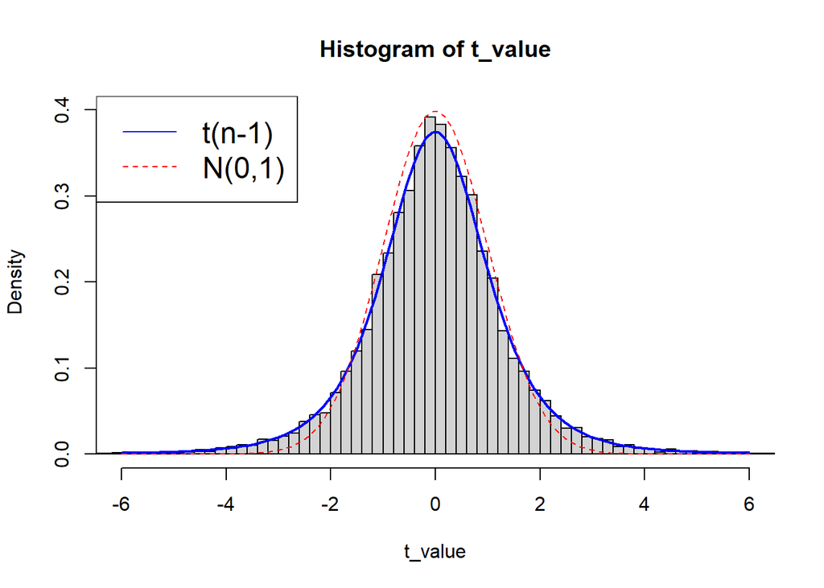

```r
n <- 5
t_value <- NULL
for (i in 1:10000) {
  rn <- rnorm(n = n, mean = 1100)
  t_value <- c(t_value, (mean(rn)-1100) / (sd(rn)/sqrt(n)))
}
hist(t_value, breaks = 200, probability = TRUE, xlim = c(-6, 6), ylim = c(0, 0.4))
# 理論上の分布 t(n-1) を重ね描き
x_vals <- seq(-6, 6, length.out = 100)
lines(x_vals, dt(x_vals, df = n-1), col = "blue", lwd = 2)  # t(n-1)
lines(x_vals, dnorm(x_vals), col = "red", lwd = 1, lty = 2)  # N (for reference)
legend(x = "topleft", legend = c("t(n-1)", "N(0,1)"), col = c("blue", "red"), lty = 1:2, cex = 1.5)
```

もし実際に観察された検定統計量の値がこの分布の端（たとえば $t=2.4$）に位置するのであれば，それは「帰無仮説が正しいときに得られる可能性が高い値（またはその範囲）から乖離した平均値が観察されていること」を意味する． このとき帰無仮説とデータは矛盾していると判断し，帰無仮説を棄却する．

帰無仮説とデータの乖離を測る指標として次の $p$ 値が計算される．

$$p = \Pr(T \ge 2.4) \quad \mbox{or}
\quad p = 2 \times \Pr(T \ge 2.4)$$

累積分布関数を用いて汎用に書けば次のようになる．

$$p = 1 - \Pr(T \le |t|) \quad \mbox{or}
\quad p = 2 \times (1 - \Pr(T \le |t|))$$

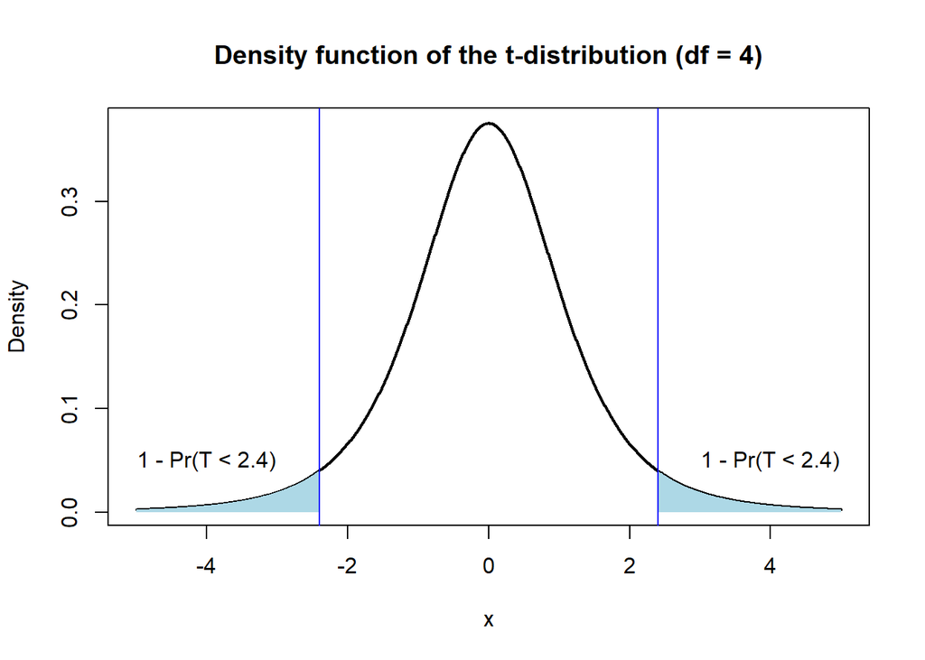

### 8.1.1 Calculation from the sample mean and sd of the data / データの標本平均・標準偏差から計算

母集団が正規分布に従っており，$\sigma$ は未知，$\bar{x} = 1230, s=170.3, n = 10, \alpha=0.05$ とする．

$$H_0: \mu = 1100, \quad H_1: \mu \ne
1100$$

$$t = \frac{\bar{x} - \mu_0}{s/\sqrt{n}}
= \frac{1230 - 1100}{170.3 / \sqrt{10}} \approx 2.41$$

$$\Pr (T \le 2.41) = 0.98 , \quad p = 2
\times (1 - \Pr (T \le 2.41)) \approx 0.039$$

```r
t_value <- (1230 - 1100) / (170.3 / sqrt(10))  # t value
t_value
```

```
## [1] 2.413952
```

```r
pt(q = t_value, df = 10 - 1)  # Pr(T <= t)
```

```
## [1] 0.9805023
```

```r
1 - pt(q = t_value, df = 10 - 1)  # one-sided p value ... p = Pr(T > t)
```

```
## [1] 0.01949773
```

```r
2 * (1 - pt(q = t_value, df = 10 - 1))  # two-sided p value
```

```
## [1] 0.03899546
```

よって，$H_0$ は棄却され $H_1$ が採択される．

### 8.1.2 Calculation from the data itself / データそのものから計算

上と同様に帰無仮説を $\mu=1100$ とする． また，標本（賃金としよう）の背後にある母集団は正規分布と仮定する．

```r
wage <- c(1000, 1200, 1300, 1200, 1150, 1000, 1450, 1500, 1150, 1350)
c(mean(wage), sd(wage), length(wage))
```

```
## [1] 1230.0000  170.2939   10.0000
```

```r
t_value <- (mean(wage) - 1100) / (sd(wage) / sqrt(length(wage)))
2 * (1 - pt(q = t_value, df = length(wage) - 1))  # two-sided p value
```

```
## [1] 0.0389899
```

`t.test(ベクトル, mu = 帰無仮説の仮説値)` 関数を使用．

```r
t.test(wage, mu = 1100)  # default: two-sided ... H1 is [mu != 1100]
```

```
##
##  One Sample t-test
##
## data:  wage
## t = 2.414, df = 9, p-value = 0.03899
## alternative hypothesis: true mean is not equal to 1100
## 95 percent confidence interval:
##  1108.179 1351.821
## sample estimates:
## mean of x
##      1230
```

帰無仮説 $\mu = \mu_0$ の $\mu_0$ の値が異なったら $p$ 値はどのように異なるか？

- `t.test` 関数で計算される p 値は `t.test(...)$p.value` で抽出できる（cf. `str(t.test(...))`）．

```r
t.test(wage, mu = 100)$p.value
```

```
## [1] 5.942946e-09
```

```r
t.test(wage, mu = 1000)$p.value
```

```
## [1] 0.002077277
```

```r
t.test(wage, mu = 1100)$p.value
```

```
## [1] 0.0389899
```

```r
t.test(wage, mu = 1200)$p.value
```

```
## [1] 0.5910512
```

```r
t.test(wage, mu = 1230)$p.value
```

```
## [1] 1
```

```r
t.test(wage, mu = 1250)$p.value
```

```
## [1] 0.718939
```

片側検定をする場合は `alternative = "greater"` または `= "less"` 引数で指定．

```r
t.test(wage, mu = 1100, alternative = "greater")  # one-sided ... H1 is [mu > 1100]
```

```
##
##  One Sample t-test
##
## data:  wage
## t = 2.414, df = 9, p-value = 0.01949
## alternative hypothesis: true mean is greater than 1100
## 95 percent confidence interval:
##  1131.284      Inf
## sample estimates:
## mean of x
##      1230
```

このように信頼区間も同時に計算してくれる．

## 8.2 $p$ and $\alpha$

$p$ 値はどのように分布し，その値と有意水準 $\alpha$ はどのような関係にあるのか？

「標準正規分布 $N(0, 1)$ から $n=100$ の乱数をドローして，その平均が 0 に等しいかどうかを検定する（$H_0: \mu = 0$ とする一標本の母平均の検定）」という手続きを1,000回繰り返し，検定で計算されたp値の分布を観察する．

設定上，帰無仮説は真である（すなわち，帰無仮説が棄却されないことが期待される）が，現実には偶然に大きな値（または小さな値）ばかりがドローされることで標本平均が 0 から大きく乖離し，帰無仮説が棄却される場合がありうる．

```r
t.test(x = 1:10)$p.value
```

```
## [1] 0.000278196
```

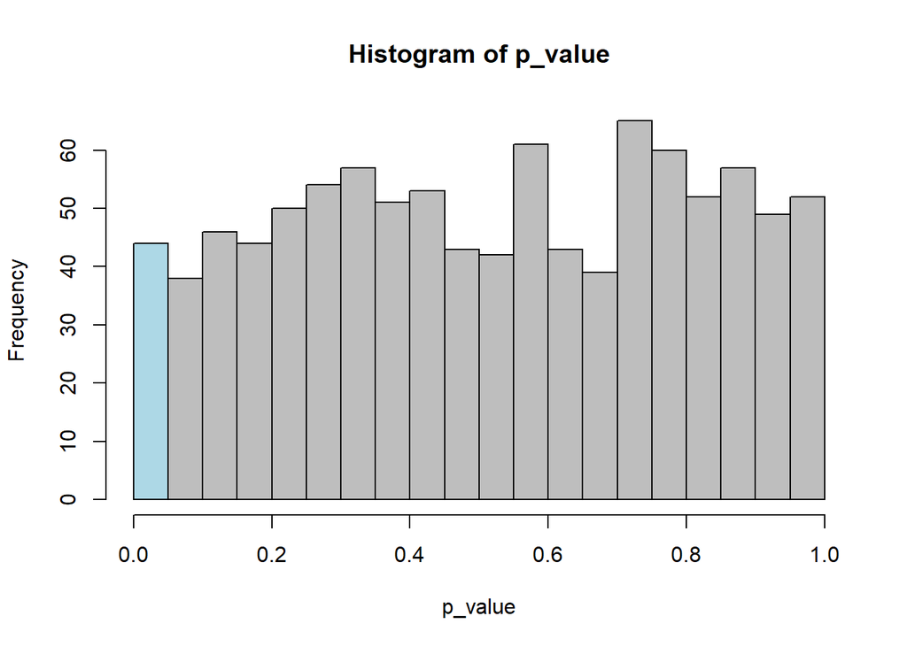

```r
p_value <- NULL
for (i in 1:1000) {
  p_value_i <- t.test(rnorm(100, mean = 0, sd = 1))$p.value
  p_value <- c(p_value, p_value_i)
}
hist(p_value, breaks = 20, col = c("lightblue", rep("grey", 19)))
```

```r
table(p_value <= 0.05)
```

```
##
## FALSE  TRUE
##   956    44
```

母集団分布の母平均は $\mu = 0$ であるからこの帰無仮説は棄却されないことが望まれるが（$p > \alpha$），上記の通り5%程度の確率で誤って棄却されてしまう（$p \le \alpha$, 第一種の過誤）．

### 8.2.1 $t$-test on a sample mean that is not normally distributed

中心極限定理による正規近似が適用できないような標本平均に対して $t$ 検定を適用したらどうなるだろうか？

歪んだ分布の例として対数正規分布 $X \sim \ln N (\mu, \sigma^2)$ を取り上げ，ここからサイズ 10 の標本を作成する． 母平均が理論上の平均値 $\exp(\mu + \sigma^2/2)$ と一致するかを検定する．

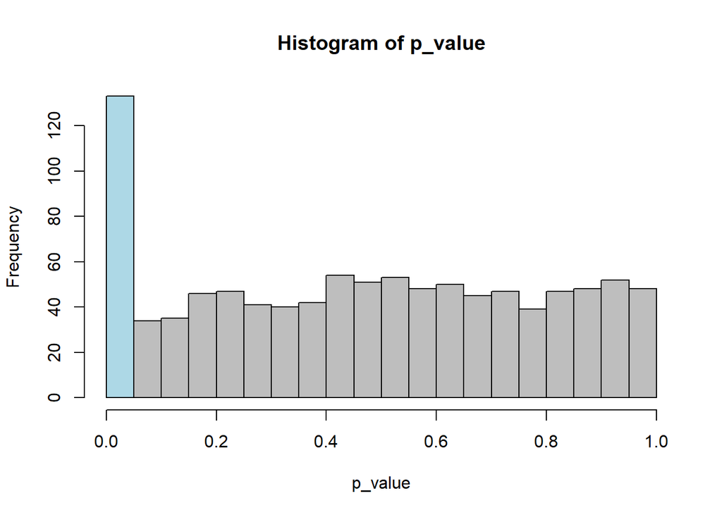

```r
p_value <- numeric(1000)  # 事前にベクトルを作成すると計算速度が向上
for (i in 1:1000) {
  p_value[i] <- t.test(rlnorm(n = 10), mu = exp(0 + 1/2))$p.value
}
hist(p_value, breaks = 20, col = c("lightblue", rep("grey", 19)))
```

```r
table(p_value <= 0.05)
```

```
##
## FALSE  TRUE
##   867   133
```

$p \le \alpha$ （第一種の過誤）となる割合が $\alpha$ より遥かに大きいことが確認できる．

## 8.3 Two-sample $t$ test for population mean / 2標本の母平均の $t$ 検定

- 独立した2標本の検定
  - 例：日本企業のアルバイトの時給 vs. 米国企業のアルバイトの時給 （いずれも円に換算したもの）
  - Welchのt検定（通常用いられる手法）
  - 等分散を仮定したt検定（通常用いられない手法）
- 対応のある2標本の検定
  - 例：同一人物における朝食前の血圧 vs. 朝食後の血圧

### 8.3.1 Independent $t$ test (Welch’s t-test)

$$T = \frac{\bar{X}_1 -
\bar{X}_2}{\sqrt{s_1^2 / n_1 + s_2^2 / n_2}} \sim t \left( \frac{[s_1^2
/ n_1 + s_2^2 / n_2]^2}{\frac{(s_1^2 / n_1)^2}{n_1 - 1} + \frac{(s_2^2 /
n_2)^2}{n_2 - 1}} \right)$$

注：t分布の自由度は正の実数（小数部分があってもよい）．

#### 8.3.1.1 Example of “wage” data

帰無仮説：日本企業（母集団）の時給平均 ＝ 米国企業（母集団）の時給平均

2つの母集団はいずれも正規分布に従うと仮定する．

```r
wage_jp <- c(1000, 1200, 1300, 1200, 1150, 1000, 1450, 1500, 1150, 1350)  # Japan
wage_us <- c(900, 1300, 1200, 800, 1600, 850, 1000, 950)  # US
c(length(wage_jp), mean(wage_jp), sd(wage_jp))
```

```
## [1]   10.0000 1230.0000  170.2939
```

```r
c(length(wage_us), mean(wage_us), sd(wage_us))
```

```
## [1]    8.0000 1075.0000  272.5541
```

定義に基づいて計算する場合．

```r
t_value <- (mean(wage_jp) - mean(wage_us)) /
  sqrt(var(wage_jp) / length(wage_jp) + var(wage_us) / length(wage_us))
df_wage <- (var(wage_jp) / length(wage_jp) + var(wage_us) / length(wage_us))^2 /
  (var(wage_jp)^2 / length(wage_jp)^2 / (length(wage_jp)-1) +
     var(wage_us)^2 / length(wage_us)^2 / (length(wage_us) - 1))
c(t_value, df_wage, pt(q = t_value, df = df_wage))
```

```
## [1]  1.4041264 11.2050309  0.9063064
```

```r
2 * (1 - pt(q = abs(t_value), df = df_wage))
```

```
## [1] 0.1873871
```

Built-in 関数を利用する場合，`t.test(x = 1つ目のベクトル, y = 2つ目のベクトル)` のように指定する．

```r
t.test(wage_jp, wage_us)  # default: Welch's t-test (allowing for unequal variances)
```

```
##
##  Welch Two Sample t-test
##
## data:  wage_jp and wage_us
## t = 1.4041, df = 11.205, p-value = 0.1874
## alternative hypothesis: true difference in means is not equal to 0
## 95 percent confidence interval:
##  -87.42307 397.42307
## sample estimates:
## mean of x mean of y
##      1230      1075
```

```r
t.test(wage_jp, wage_us, var.equal = TRUE)  # t-test (assuming equal variances)
```

```
##
##  Two Sample t-test
##
## data:  wage_jp and wage_us
## t = 1.479, df = 16, p-value = 0.1586
## alternative hypothesis: true difference in means is not equal to 0
## 95 percent confidence interval:
##  -67.16377 377.16377
## sample estimates:
## mean of x mean of y
##      1230      1075
```

#### 8.3.1.2 Titanic data

データ読み込み．

```r
titanic <- read.csv("https://raw.githubusercontent.com/kurodaecon/bs/main/data/titanic3_csv.csv")
```

性別によって年齢の平均値が異なるかどうかの検定．

```r
age_female <- titanic$age[titanic$sex == "female"]
age_male   <- titanic$age[titanic$sex == "male"]
t.test(x = age_female, y = age_male)
```

```
##
##  Welch Two Sample t-test
##
## data:  age_female and age_male
## t = -2.0497, df = 798.36, p-value = 0.04072
## alternative hypothesis: true difference in means is not equal to 0
## 95 percent confidence interval:
##  -3.71593356 -0.08034711
## sample estimates:
## mean of x mean of y
##  28.68709  30.58523
```

`t.test(変数 ~ グループ, data = dataset)` で，2つのグループ間の検定が可能．

```r
t.test(age ~ sex, data = titanic)  # same as above
```

```
##
##  Welch Two Sample t-test
##
## data:  age by sex
## t = -2.0497, df = 798.36, p-value = 0.04072
## alternative hypothesis: true difference in means between group female and group male is not equal to 0
## 95 percent confidence interval:
##  -3.71593356 -0.08034711
## sample estimates:
## mean in group female   mean in group male
##             28.68709             30.58523
```

サブサンプルに対して検定する場合やデータフレームを加工して作成した変数を用いて検定する場合はパイプ演算子を使うと便利（`tidyverse` が必要）．

- `t.test` の直前のパイプ演算子より前の部分（データフレーム）が `t.test` 関数の第一引数にならないため，`t.test` 関数内で `data = .` を明示的に書く必要がある（`.` がパイプ演算子の前の部分を受け取る）

```r
library(tidyverse)
titanic %>%
  filter(pclass == 1) %>%
  t.test(age ~ sex, data = .)
```

```
##
##  Welch Two Sample t-test
##
## data:  age by sex
## t = -2.3283, df = 278.85, p-value = 0.02061
## alternative hypothesis: true difference in means between group female and group male is not equal to 0
## 95 percent confidence interval:
##  -7.3664537 -0.6169013
## sample estimates:
## mean in group female   mean in group male
##             37.03759             41.02927
```

### 8.3.2 Paired (dependent) $t$ test

対応のある t 検定は `t.test` の引数で `paired = TRUE` 引数を追加して計算する．

帰無仮説：妻（母集団）の時給平均 ＝ 夫（母集団）の時給平均

2つの母集団はいずれも正規分布に従うと仮定する．

```r
wage_w <- c(1000, 1200, 1300, 1200, 1150, 1000, 1450, 1500, 1150, 1350)  # wife
wage_h <- c(900, 1300, 1200, 800, 1600, 850, 1000, 950, 1200, 1400)  # husband
# length(wage_w); length(wage_h)  # = 10
t.test(wage_w, wage_h, paired = TRUE)
```

```
##
##  Paired t-test
##
## data:  wage_w and wage_h
## t = 1.1638, df = 9, p-value = 0.2744
## alternative hypothesis: true mean difference is not equal to 0
## 95 percent confidence interval:
##  -103.8108  323.8108
## sample estimates:
## mean difference
##             110
```

以下の通り「要素ごとの差」という一標本の検定と同値．

```r
wage_diff <- wage_w - wage_h
t.test(wage_diff)  # ordinary "one-sample t-test"
```

```
##
##  One Sample t-test
##
## data:  wage_diff
## t = 1.1638, df = 9, p-value = 0.2744
## alternative hypothesis: true mean is not equal to 0
## 95 percent confidence interval:
##  -103.8108  323.8108
## sample estimates:
## mean of x
##       110
```

## 8.4 Multiple testing problem: Simulation / 多重検定の問題に関するシミュレーション

概要：複数の標本（または複数の標本組み合わせ）に関する帰無仮説を独立して検定すると，そのうち少なくとも一つで誤って帰無仮説を棄却する確率が事前に設定した有意水準（5%など）を上回ってしまう．

例：A と B という2つの母集団の平均がどちらも0に等しいかどうかを検定したい．帰無仮説は「$\mu_A = \mu_B = 0$」である．このとき，この帰無仮説を $\mu_A=0, \mu_B=0$ という2標本の平均の差の検定が適用できる2つの帰無仮説を組み合わせたものとして捉え，「2つの検定を行ってどちらか1つでも帰無仮説が棄却されたら大元の帰無仮説を棄却する」という判定方法がもし有効であれば，検定は簡単である．しかし，この判定方法は有効ではない．

上記をシミュレーションを通して観察するために，「期待値 0 の母集団から乱数をドローして標本平均を計算し，帰無仮説 $\mu=0$ が棄却されるかを検定する」という一連の手続きを繰り返し行おう． 有意水準を5%と設定するとき，我々は第一種の過誤（帰無仮説が誤って棄却されること）が5%の割合で生じることを許容しているはずである．

### 8.4.1 One null hypothesis

1,000 の標本のうち「1つ」について $H_0: \mu = 0$ を有意水準 $\alpha = 0.05$ で検定した場合，帰無仮説が誤って棄却されてしまう理論上の割合は有意水準である5%．

$$1 -
\mbox{(1つの標本について棄却されない確率)} = 1 - (1 - 0.05) = 0.05$$

シミュレーション上は以下の通り（概ね5%）．

```r
p_value <- NULL
for (i in 1:1000) {
  p_value_i <- t.test(rnorm(100, mean = 0, sd = 1))$p.value
  p_value <- c(p_value, p_value_i)
}
table(p_value <= 0.05)
```

```
##
## FALSE  TRUE
##   959    41
```

### 8.4.2 Two null hypothesis

1,000 の標本のうち「2つ」について $H_0: \mu = 0$ を検定した場合，少なくともどちらか一方で帰無仮説が誤って棄却されてしまう割合は以下の通り（概ね10%）．

$$1 - \mbox{(2回とも棄却されない確率)} =
1 - (1 - 0.05)^2 = 0.0975$$

- `sapply(X = ベクトル, FUN = 関数)` ：ベクトルの要素を1つずつ関数で評価しその結果をベクトルで返す
- `sample(ベクトル, 個数)` ：指定した個数分だけベクトルからランダムにサンプリング
- `any(論理値ベクトル)` ：論理値ベクトルの要素の1つ以上が TRUE の場合に TRUE を返す

```r
table(sapply(X = 1:1000, FUN = function(x) any(sample(p_value, 2) <= 0.05)))
```

```
##
## FALSE  TRUE
##   920    80
```

### 8.4.3 Five null hypothesis

1,000 の標本のうち「5つ」について $H_0: \mu = 0$ を検定した場合，少なくとも1つで帰無仮説が誤って棄却されてしまう割合は以下の通り（概ね23%）．

$$1 - (1 - 0.05)^5 \approx 0.226$$

```r
table(sapply(X = 1:1000, FUN = function(x) any(sample(p_value, 5) <= 0.05)))
```

```
##
## FALSE  TRUE
##   814   186
```

### 8.4.4 Proper method: ANOVA

上記の通り，2標本のt検定を繰り返し行うことはNG． このような多群間の比較を行いたいときは，分散分析（ANOVA）が適用できる場合がある．

例：同一母集団から3つの標本を作成し分散分析を適用する． 同一母集団からのサンプリングであるので，次の帰無仮説が棄却される割合は有意水準（5%など）に一致するはず．

帰無仮説：$\mu_1 = \mu_2 = \mu_3$

```r
df <- data.frame(val = rnorm(100 * 3), group = rep(1:3, 100))
head(df)
```

```
##          val group
## 1  1.0577203     1
## 2 -1.1384606     2
## 3 -0.6858787     3
## 4  0.5266031     1
## 5  1.9954372     2
## 6  1.4417576     3
```

```r
summary(aov(val ~ group, data = df))
```

```
##              Df Sum Sq Mean Sq F value Pr(>F)
## group         1    2.5   2.454   2.134  0.145
## Residuals   298  342.6   1.150
```

```r
summary(aov(val ~ group, data = df))[[1]]$`Pr(>F)`[1]  # extract p-value
```

```
## [1] 0.1450799
```

以下のように $p$ 値の分布を確認できる．

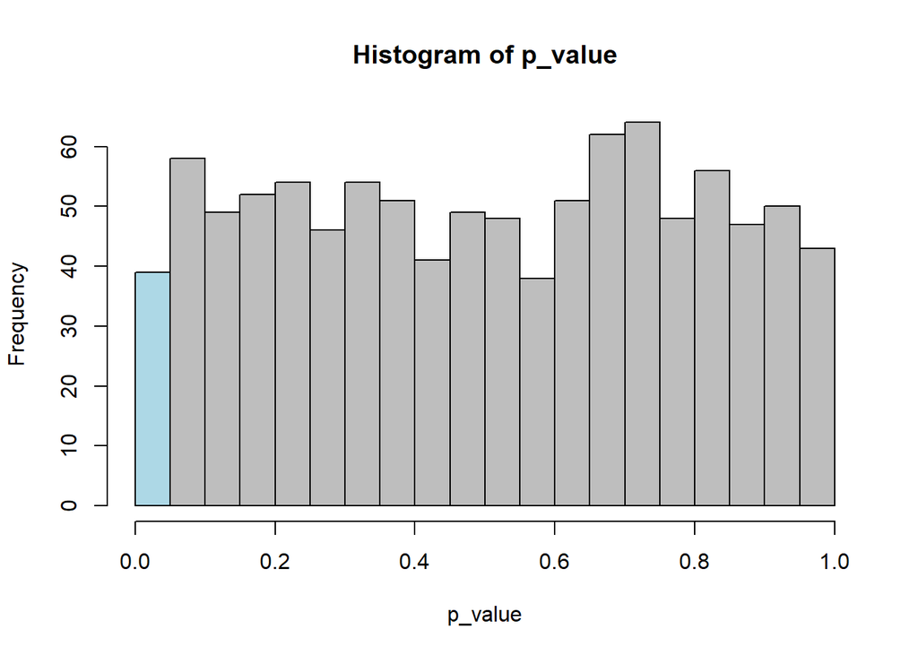

```r
p_value <- NULL
for (i in 1:1000) {
  df_i <- data.frame(val = rnorm(100 * 3), group = rep(1:3, 100))
  p_i <- summary(aov(val ~ group, data = df_i))[[1]]$`Pr(>F)`[1]
  p_value <- c(p_value, p_i)
}
hist(p_value, breaks = 20, col = c("lightblue", rep("grey", 19)))
```

```r
table(p_value <= 0.05)
```

```
##
## FALSE  TRUE
##   961    39
```